# What changes when a model starts asking the questions?

Session 6 · AI-assisted and AI-led interviewing

Generative AI in Sociology

2026-10-07

## Two interviewers respond differently to the same hiring judgment

Interviewer: Tell me about a recent candidate who seemed like a good fit for the firm.

Evaluator: The conversation flowed. We had a surprising amount in common.

Interviewer: What did you find you had in common?

Evaluator: We had both rowed in college and talked about long training days.

Interviewer: Tell me about a recent candidate who seemed like a good fit for the firm.

Evaluator: The conversation flowed. We had a surprising amount in common.

Interviewer: So their background matched the firm’s culture?

Evaluator: Yes, I suppose so.

## What did you use to make that judgment?

The room may have used several standards without naming them:

| Standard | Where it comes from | Question |
| --- | --- | --- |
| Specificity and nondirection | Merton & Kendall (1946) | Did the probe obtain a concrete account without supplying it? |
| Procedural comparability | Fowler & Mangione (1990) | Did interviewer discretion vary across participants? |
| Relationship and reciprocity | Oakley (2016); Bourdieu (1996) | Who is asking, and what does the participant think this relationship is? |
| Claim–evidence fit | Jerolmack & Khan (2014) | What can this account actually establish? |

Merton & Kendall, 1946, *AJS* 51(6): 541–557; Fowler & Mangione, 1990, *Standardized Survey Interviewing*; Oakley, 2016, *Sociology* 50(1): 195–213; Bourdieu, 1996, *Theory, Culture & Society* 13(2): 17–37; Jerolmack & Khan, 2014, *Sociological Methods & Research* 43(2): 178–209.

## There is no universal winner—and that is the point

### Interview A

Asks the evaluator to specify what “in common” meant in this case.

**Risk:** the follow-up creates a participant-specific path.

### Interview B

Offers “firm culture” as the explanation before the evaluator has done so.

**Risk:** agreement may reflect the wording of the probe rather than the evaluator’s original account.

**The right answer depends on the claim.** If the study asks how evaluators construct cultural fit, A currently gives better evidence. If it requires a standardized measure of fit, neither exchange is an adequate instrument.

## Three questions will let us make that judgment properly

**Evidence**  
What should the interview establish?

→

**Discretion**  
What may the interviewer do?

→

**Relationship**  
Who or what is asking?

The first question clarifies the research purpose. The second lets us inspect the probe. The third asks how the encounter itself shapes the answer.

## The two opening interviews already show what is new

| Same before the answer | Different after the answer |
| --- | --- |
| Research question Fixed opening question Instructions about probing | **A:** asks what “in common” meant **B:** supplies “firm culture” as the interpretation |

Once the next question depends on the answer, the interview protocol is no longer a complete record of what each participant received.

## This extends the treatment problem from last week

|  | Set in advance | Can change |
| --- | --- | --- |
| Fixed vignette | Wording and exposure | Participant response |
| Adaptive item bank | Pool and selection rule | Next item across respondents |
| Adaptive interview | Protocol and instructions | Next probe within a conversation |

The guide or system prompt no longer completely describes the interview a participant received.

## Early Chicago sociology connected biographies to social change

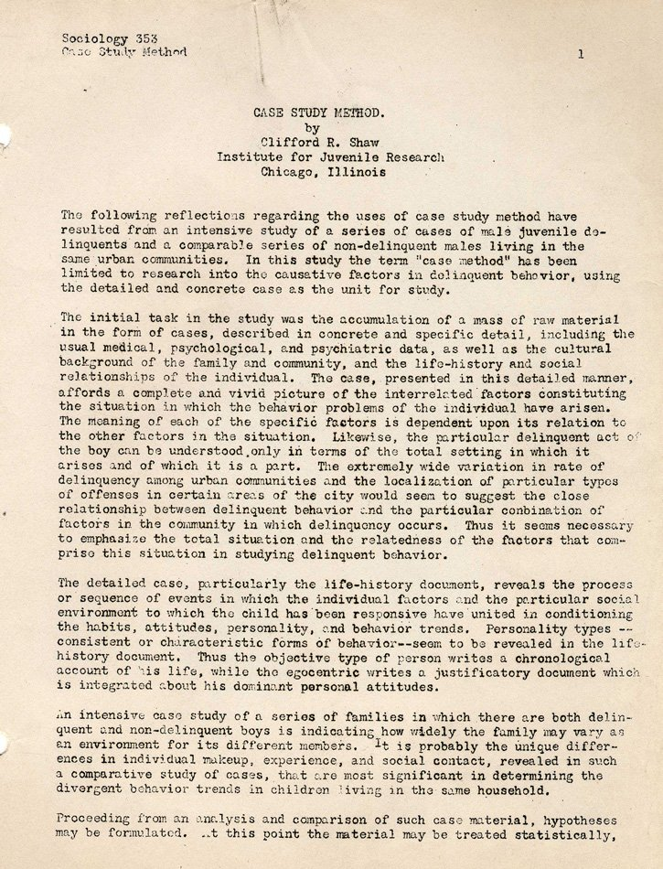

The University of Chicago archive describes life histories as interviews or autobiographical accounts used to connect a person’s experience with a changing social world.

This student paper also shows that the researcher selected, organized and interpreted the life record.

**Question added:** Is one interview adequate to the timescale and context of the claim?

C. R. Shaw student paper, Sociology 353, Ernest Watson Burgess Papers, University of Chicago Library.

## A transcript is a record of a life, not the life itself

If our claim concerns how class, migration or institutional experience develops over time, a fluent twenty-minute account can still be too thin.

What would we need besides a transcript to understand a student’s route into—and through—graduate education?

## Merton and Kendall studied responses to situations the researchers already knew

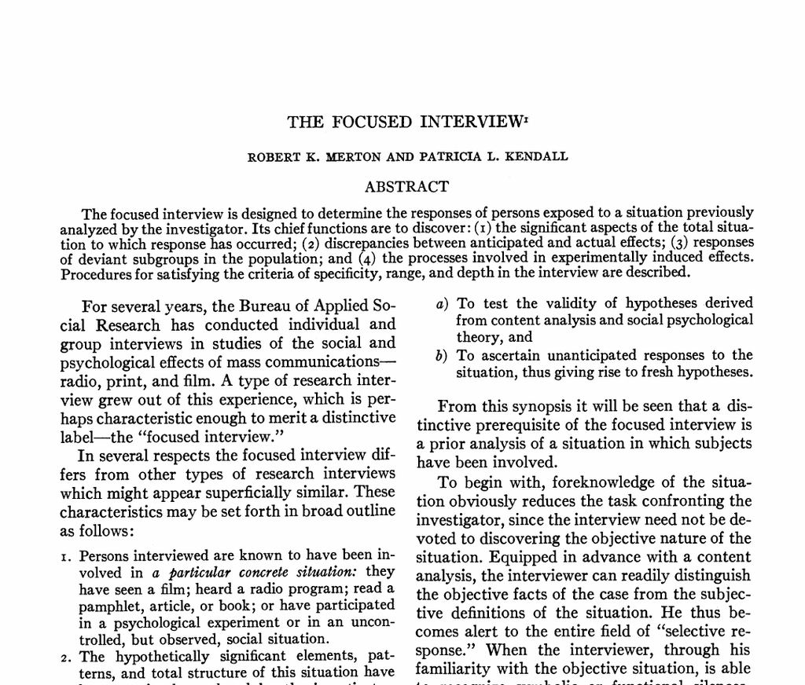

The focused interview developed from research on responses to analysed films, broadcasts and experimental situations.

The prior analysis gave interviewers expectations to investigate—but the interview still had to leave room for unanticipated responses.

Robert K. Merton & Patricia L. Kendall (1946), “The Focused Interview,” *American Journal of Sociology* 51(6): 541–557. https://doi.org/10.1086/219886

## These are Merton and Kendall’s own four criteria

They call the criteria **provisional** and interrelated:

1. nondirection;
2. specificity;
3. range;
4. depth and personal context.

The formulation matters: “depth” is not a word-count metric. It concerns affective significance and personal context.

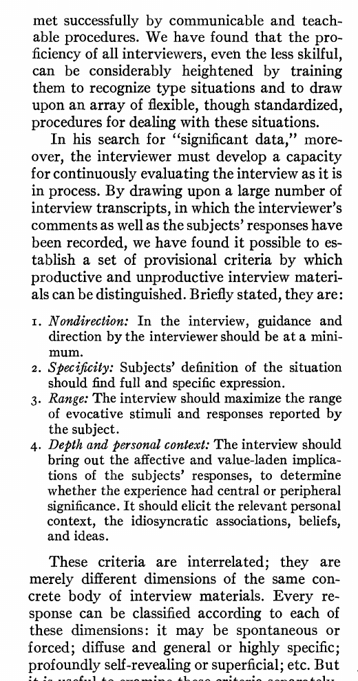

Merton & Kendall (1946), p. 545. Screenshot from the supplied published PDF.

## The four criteria can pull the interviewer in different directions

| The criterion | What the paper asks the interviewer to notice |
| --- | --- |
| Nondirection | Keep guidance to a minimum so the participant’s own framing can appear. |
| Specificity | Obtain a full and specific definition of the situation. |
| Range | Cover anticipated and unanticipated responses and stimuli. |
| Depth and personal context | Distinguish central, affect-laden responses from peripheral ones and connect them to prior experience. |

These are not four independent scores. The interviewer evaluates the conversation as it proceeds and adapts technique accordingly.

## A useful probe asks for evidence without supplying the answer

Response: “I found it uncomfortable.”

Probe A: “Was there a particular moment when you began to feel uncomfortable?”

Probe B: “Was it the speaker’s dismissive tone that made you uncomfortable?”

This is an instructor-written example applying Merton and Kendall’s distinction. Probe A requests specificity. Probe B introduces both a feature and an interpretation.

**Check:** Does the probe obtain specificity or depth while keeping direction to a minimum?

Applied example based on Merton & Kendall (1946), especially pp. 545–551.

## Survey interviewing gave the interviewer a different job

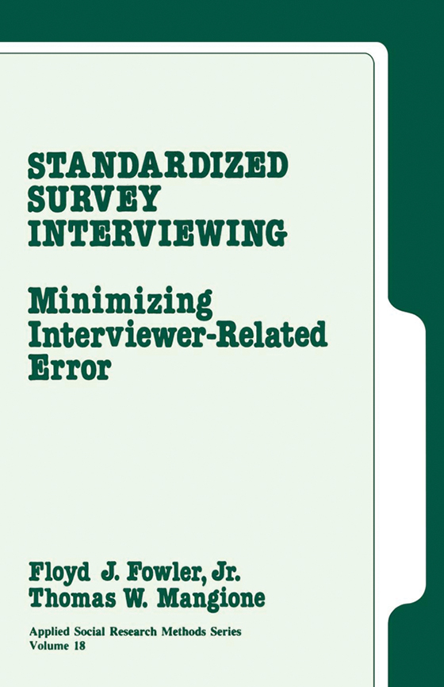

### Read as written

Keep wording and order stable.

### Use standardized probes

Do not improvise different explanations for different respondents.

### Follow skip logic and code consistently

The interviewer’s role is deliberately restricted.

Floyd J. Fowler Jr. & Thomas W. Mangione (1990), *Standardized Survey Interviewing: Minimizing Interviewer-Related Error*. SAGE.

Standardization reduces one source of interviewer-related variation for a measurement task. It does not remove all interviewer effects or guarantee shared interpretation.

## Identical wording does not guarantee identical meaning

Interviewer: In the last week, how many times did you exercise?

Respondent: Does walking to work count?

Strict: Whatever exercise means to you.

Clarifying: Count walking if it lasted ten minutes and raised your breathing rate.

The first preserves the standardized script. The second may improve the respondent’s mapping to the intended concept, but changes the words this respondent hears.

Illustrative exercise based on Schober & Conrad (1997), “Does Conversational Interviewing Reduce Survey Measurement Error?”, *Public Opinion Quarterly* 61(4): 576–602.

## Depth and comparability are different research objectives

| Interview job | Interviewer does | Main risk |
| --- | --- | --- |
| Reconstruct a process | Follows chronology and context | Short accounts detach events from a life |
| Understand a response | Requests specificity and depth | The probe directs the answer |
| Produce comparable measures | Restricts discretion | Shared wording conceals different meanings |

Instructor synthesis of Thomas & Znaniecki’s life-history tradition; Merton & Kendall (1946); Fowler & Mangione (1990); and Schober & Conrad (1997). The table is not reproduced from a single source.

## Interviewing also involves trouble and repair

Respondents hesitate, challenge a category, answer a different question, or reveal that interviewer and respondent do not share the same definition.

The respondent’s request—“Does walking count?”—shows why we now need to consider the exchange itself, not only the schedule.

This is the bridge: standardization asks what the interviewer should keep fixed; interaction research asks what happens when shared meaning breaks down.

## Repair makes the interviewer’s contribution visible

When a respondent asks what a category means, the interviewer has to do something: repeat the words, provide a definition, improvise an explanation, defer, or move on.

### What the transcript records

The exact clarification and the answer that followed it.

### What the methods section must explain

Which clarifications were allowed, how interviewers were trained, and whether different respondents received different explanations.

This is why interviewer behavior is part of the data-generating process rather than an incidental feature of delivery.

## Oakley’s argument came from interviewing women becoming mothers

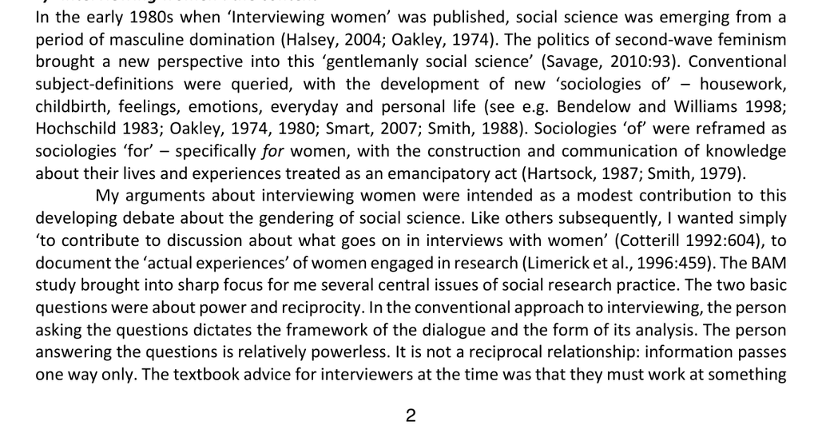

Oakley’s original argument grew from the *Becoming a Mother* study: four interviews each with 55 women from pregnancy to five months after birth.

The participants asked Oakley hundreds of questions about pregnancy, childbirth and care. Conventional advice said that answering could bias the data; Oakley argued that refusing could be exploitative and counterproductive.

Ann Oakley (2016), “Interviewing Women Again: Power, Time and the Gift,” *Sociology* 50(1): 195–213. https://doi.org/10.1177/0038038515580253

## Oakley makes power and reciprocity part of the method

“The two basic questions were about power and reciprocity.”

The person asking questions ordinarily sets the framework and later controls the analysis. Information does not simply pass between equal parties. Rapport may also invite disclosures that create ethical obligations.

**For AI interviews:** removing the human interviewer changes the relationship; it does not remove institutional power, expectations about listening, or responsibility for what is disclosed.

Oakley (2016), pp. 197–199. Quotation contains 9 words.

## Bourdieu begins from the same premise, but stresses social structure

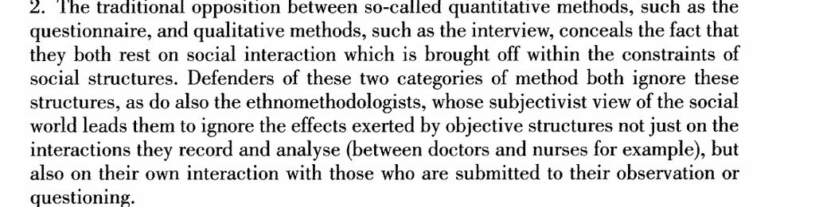

Pierre Bourdieu (1996), “Understanding,” *Theory, Culture & Society* 13(2): 17–37, p. 34, note 2. https://doi.org/10.1177/026327696013002002. Screenshot from the published PDF.

## For Bourdieu, good listening requires active work

He describes verbal and bodily signs of attention—“yes,” “right,” nods, looks and smiles—as conditions for a conversation that flows. A moment of inattention can make the respondent lose the thread.

### What an AI system can imitate

Acknowledgments, paraphrases, pauses and follow-up questions.

### What remains an empirical question

Whether participants interpret those signals as attention, institutional surveillance, empty fluency or something else.

Bourdieu (1996), note 4; see also pp. 17–37 for the interviewing principles developed for *La Misère du Monde*.

## The relationship affects the account—but the account still has limits

“When senior students are in the room, I decide not to speak because I assume their comments will be more sophisticated.”

1. The participant **described** worrying about intellectual worth.
2. The account may help analyse how students **understand** participation.
3. It does not by itself show the participant **always remains silent** around senior students.

## Jerolmack and Khan call this the “attitudinal fallacy”

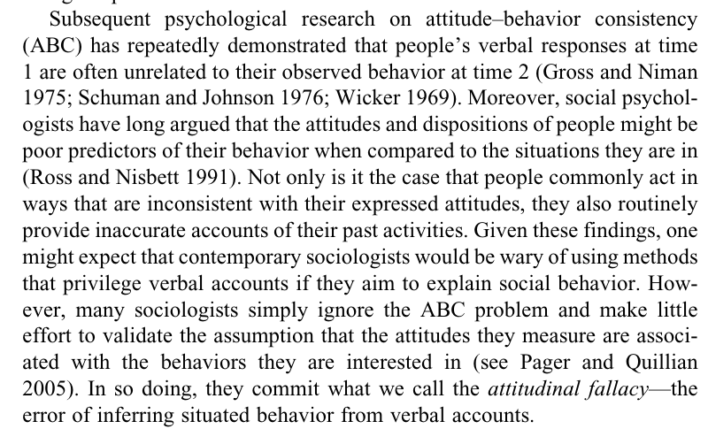

The mistake is not listening to an account. It is treating what someone says as evidence of how they behave in a particular situation, without showing that the two are linked.

**Criterion 4:** Does the claim stay within what the interview evidence can establish?

**Their first example is LaPiere:** did proprietors’ later answers match what happened when they actually encountered a Chinese couple?

Colin Jerolmack & Shamus Khan (2014), “Talk Is Cheap: Ethnography and the Attitudinal Fallacy,” *Sociological Methods & Research* 43(2): 178–209, p. 179. https://doi.org/10.1177/0049124114523396.

## LaPiere observed one pattern, then heard almost the reverse

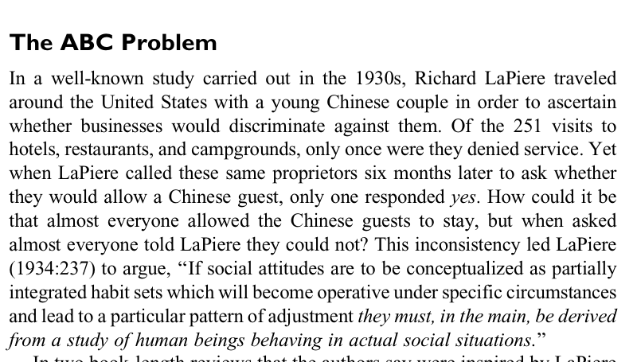

1. LaPiere travelled with a young Chinese couple in the 1930s.
2. They were denied service only once in 251 visits.
3. Six months later, only one proprietor said they would admit a Chinese guest.

The later answer did not predict conduct during the earlier encounter.

Jerolmack & Khan (2014), p. 182, discussing LaPiere (1934). Screenshot from the published article.

## The budgeting example shows why the discrepancy may be situational

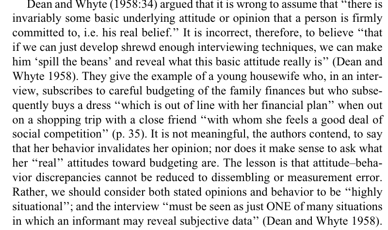

**In the interview:** a woman endorses careful family budgeting.

**While shopping with a friend:** she buys a dress outside the plan amid “social competition.”

Jerolmack and Khan’s point is not that one response reveals her “real” attitude. The interview and the shopping trip are different social situations.

Jerolmack & Khan (2014), p. 183, discussing Dean & Whyte (1958). Screenshot from the published article. Quoted phrases contain 5 words.

## Their argument is not that interviews are useless

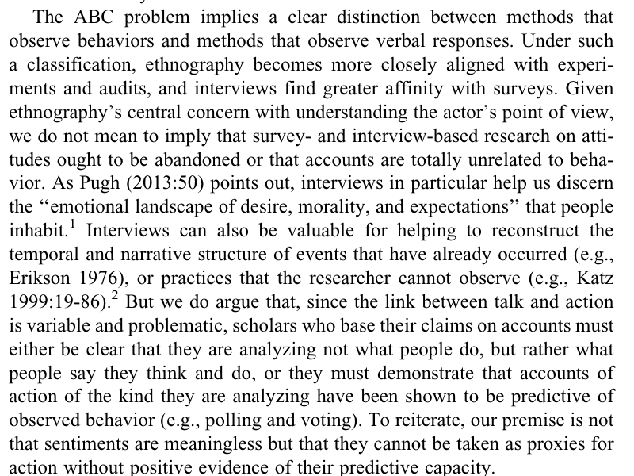

### Interviews can tell us about

meanings, expectations, retrospective narratives and practices that cannot be directly observed.

### A claim about action needs more

Observation, triangulation, or evidence that this kind of account predicts the behaviour being claimed.

Jerolmack & Khan (2014), p. 180. Screenshot from the published article.

## Rivera uses interviews to explain how employers judge “fit”

[figure not shown]

The study draws on **120 interviews** with evaluators in elite professional-service firms and participant observation of one hiring committee.

Rivera argues that hiring is not only skills sorting. Evaluators also match candidates to themselves and to an image of the firm.

This gives us a substantive question for the rest of the lecture: what must an interviewer ask to show how a judgment of fit was made?

Rivera, L. A. (2012). “Hiring as Cultural Matching: The Case of Elite Professional Service Firms.” *American Sociological Review* 77(6):999–1022. https://doi.org/10.1177/0003122412463213.

## Interviews and observation contribute different evidence

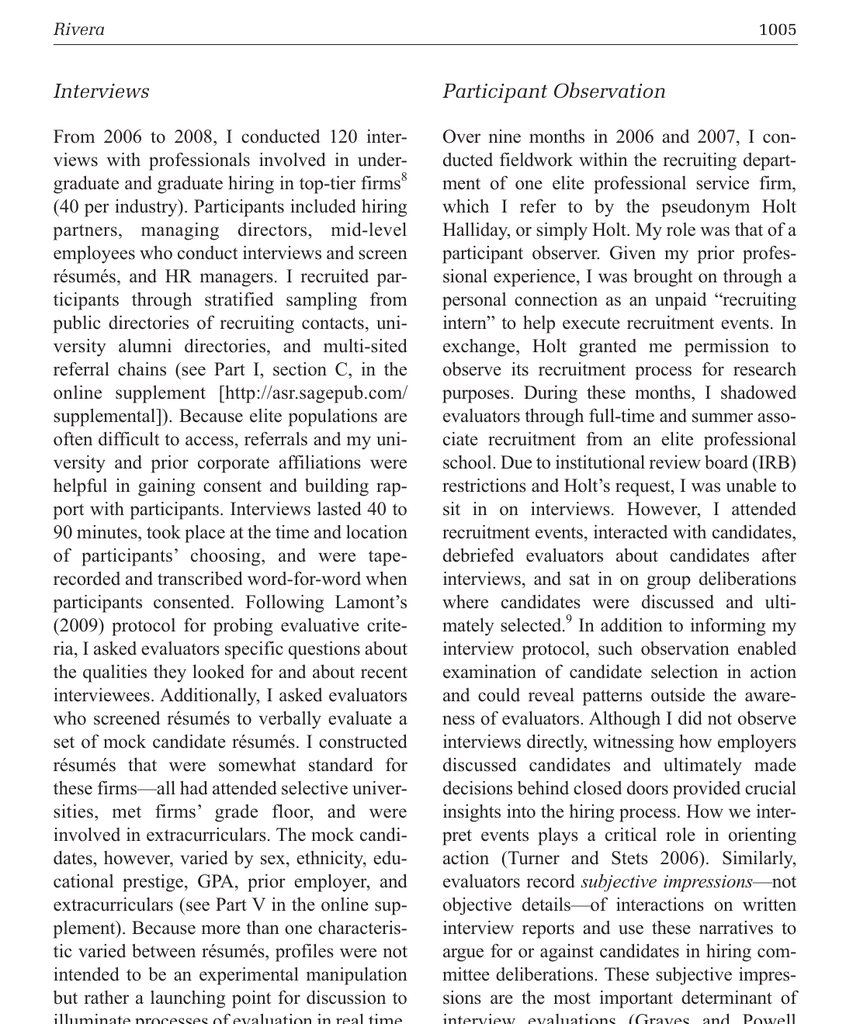

**Interviews:** evaluators explained criteria, assessed mock résumés and discussed recently interviewed candidates.

**Observation:** committee meetings showed how candidate evaluations were produced and contested in real time.

The two sources do not do the same job. The interview reveals evaluators’ accounts; observation shows parts of the decision process outside those accounts.

Rivera (2012), pp. 1004–1005. Screenshot from the published article.

## “Cultural fit” was not one single criterion

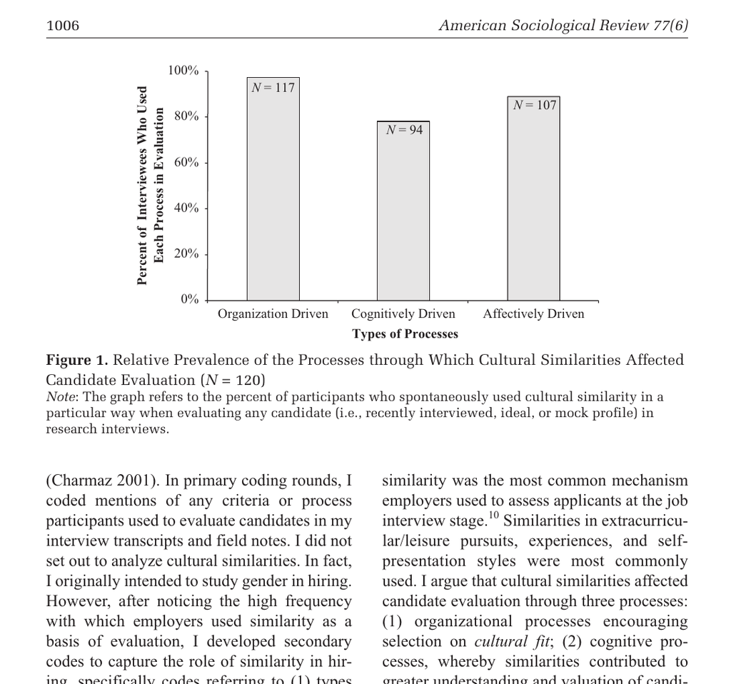

Rivera coded several processes through which similarity affected evaluation.

Evaluators used similarity to sort candidates into a firm type, interpret answers and generate feelings of excitement or connection.

A probe that merely asks “Was the candidate a good fit?” would miss these distinctions.

Rivera (2012), Figure 1 and accompanying discussion, pp. 1005–1006.

## A useful probe asks how the judgment was made

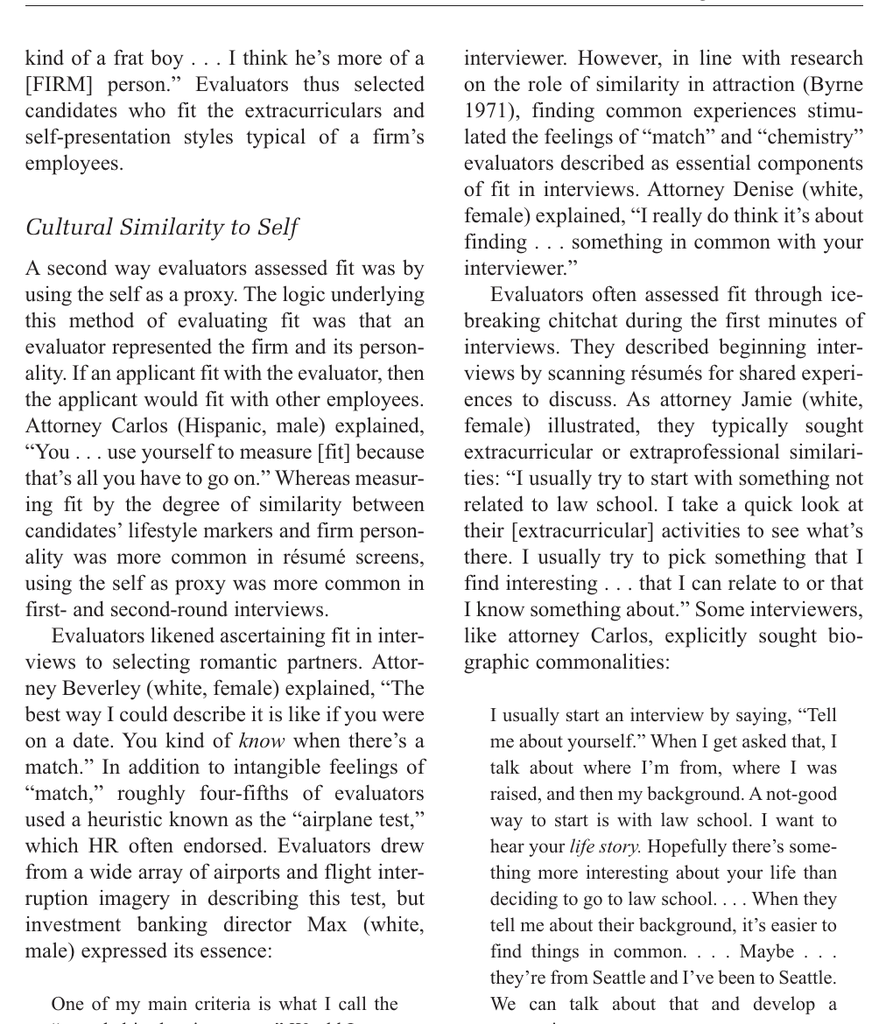

Evaluators described using themselves as a proxy for the firm and looking for shared experiences during informal conversation.

**Useful follow-up:** “What did you and the candidate find you had in common?”

**Leading follow-up:** “So their elite background made them fit the firm?”

The first asks for evidence. The second inserts the researcher’s explanation.

Rivera (2012), “Cultural Similarity to Self,” pp. 1010–1011.

## A second question is how the interview was administered

### What did the probe elicit?

Rivera’s case shows why the wording of a follow-up matters for the substantive explanation.

→

### Who or what delivered it?

Survey researchers show that an interviewer, a screen or a recorded voice can also change what people report.

These are different methodological questions. Both matter when we evaluate an AI-led interview.

## CAPI and CASI changed who presented the question

CAPI

**Computer-assisted personal interviewing.**

A human interviewer reads the item from a computer and enters the answer. The software manages question order and skips.

CASI

**Computer-assisted self-interviewing.**

The participant reads the item and enters an answer without the interviewer seeing each response.

The software changes administration and privacy. The next question is still selected from rules written in advance.

Tourangeau & Smith (1996), “Asking Sensitive Questions,” *Public Opinion Quarterly* 60(2): 275–304. https://doi.org/10.1086/297751

## Audio-CASI added recorded speech to self-administration

[figure not shown]

The participant hears a prerecorded question through headphones and selects an answer on the device.

This offers privacy without requiring every participant to read the questionnaire unaided. An enumerator may remain nearby for setup but does not administer each sensitive item.

Photograph: Oxford Mind & Behaviour Research Group, “Surveying on Sensitive Topics: Using Audio Computer Assisted Self-Interviewing.”

## The three modes create different experiences for the respondent

| Mode | Question arrives through | Who can immediately observe the answer? | Branching |
| --- | --- | --- | --- |
| CAPI | Human interviewer | Interviewer | Written in advance |
| CASI | Text on screen | Participant | Written in advance |
| Audio-CASI | Recorded voice and screen | Participant | Written in advance |

This gives us a baseline for deciding what is genuinely new about model-led interviewing.

## Tourangeau and Smith tested whether mode changed sensitive reports

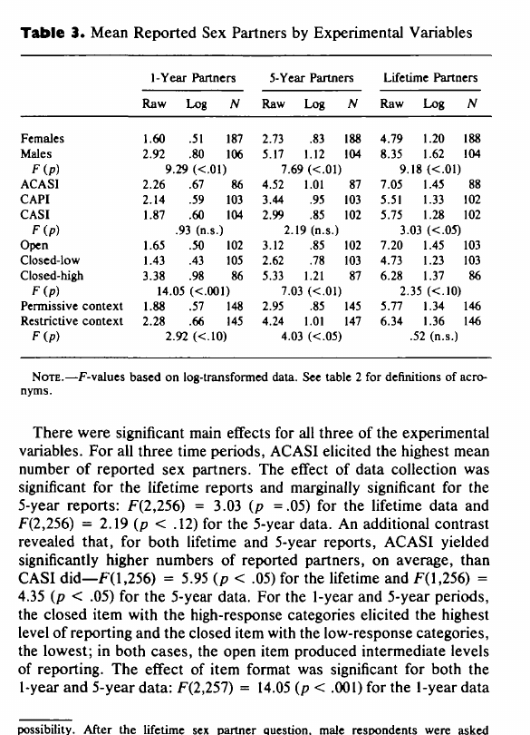

**Finding:** audio-CASI produced the highest mean reported number of sex partners. The mode effect was significant for lifetime reports; audio-CASI was also significantly higher than CASI for five-year and lifetime reports.

**Caution:** higher reporting may indicate greater disclosure. It is not automatically proof of greater accuracy.

Roger Tourangeau & Tom W. Smith (1996), *POQ* 60(2): 275–304, Table 3, pp. 292–293.

## The new capability is making an interviewing decision from an open answer

Pre-LLM systems could present items, implement complex branching and reduce interviewer presence. The branches were generally written in advance.

*An LLM can select or compose a substantive follow-up during the exchange.*

## Break

When we return: what kinds of systems are called “AI interviews,” and what do current evaluations actually show?

## The phrase “AI interview” covers quite different arrangements

| Who decides the next question? | Example in the literature | What must be recorded? |
| --- | --- | --- |
| Script and authored branches | CASI and audio-CASI in Tourangeau & Smith (1996) | Questionnaire version and branch |
| Model suggests; human interviewer decides | Uses proposed by the interview researchers in Liu et al. (2025) | Suggestion, human edit and decision |
| Model writes and delivers the question | Wuttke et al. (2025); Cuevas et al. (2025); Geiecke & Jaravel (2026) | Conversation context, output, model and settings |

## Liu et al. asked interview researchers what support they would use

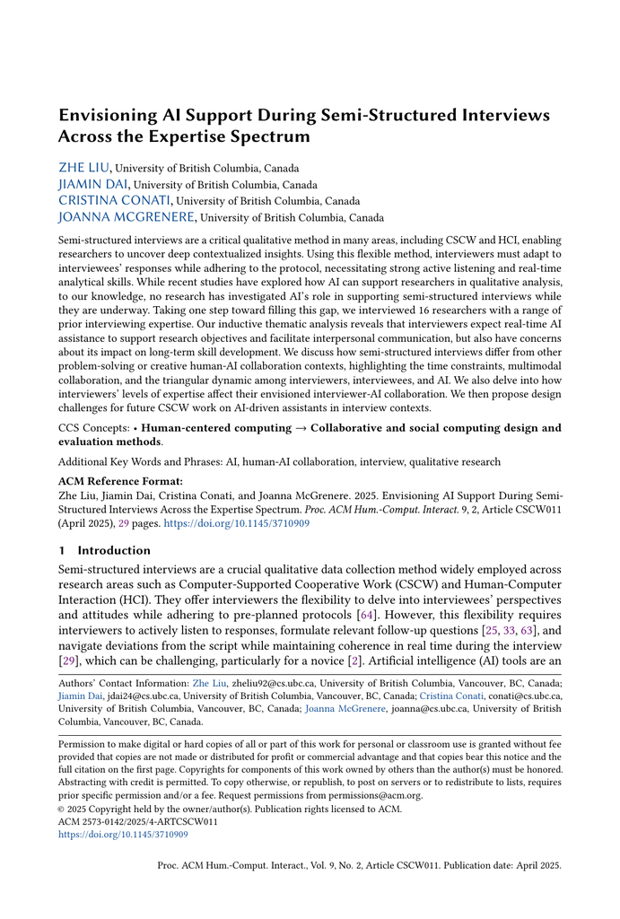

**Participants:** 16 researchers with different levels of interviewing experience.

**Method:** 50–80 minute semi-structured interviews, followed by inductive thematic analysis.

**Question:** Where might AI help a human interviewer, and where might it create new problems?

This was a study of researchers’ expectations. It did not test an AI assistant during field interviews.

Zhe Liu, Jiamin Dai, Cristina Conati & Joanna McGrenere (2025), “Envisioning AI Support During Semi-Structured Interviews Across the Expertise Spectrum,” *Proceedings of the ACM on Human-Computer Interaction* 9(2), Article CSCW011. https://doi.org/10.1145/3710909

## The most common request was help choosing a follow-up

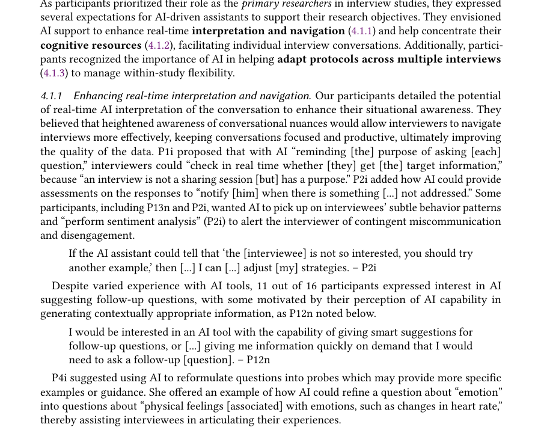

**11 of 16 researchers** expressed interest in AI suggestions for follow-up questions.

Others wanted reminders about the purpose of a question, information that had not yet been covered, or a point worth revisiting.

Researchers also worried about distraction, over-reliance and whether the system could understand the interview well enough to help.

Liu et al. (2025), section 4.1.1, pp. 9–11. Screenshot from the published article.

## An AI interviewer uses each answer to decide what to ask next

**Protocol**  
research aims and required topics

**Conversation**  
ordered questions and answers

**Model call**  
instructions plus relevant context

**Next question**  
generated text

**Decision record**  
what was sent and returned

Save the conversation sent to the model, the exact question it returned, and any human edit or approval. Otherwise we cannot reconstruct why this particular probe appeared here.

## The same logic can sit behind several access routes

### Direct API

Your code calls one provider. Check its retention, region, model version and data-use settings.

### OpenRouter

One SDK can call models from several providers. Record the selected provider as well as the model.

### Local / Ollama

Inference can stay on controlled hardware, but the model must fit and local security still matters.

A local interviewer is not fully local if audio is sent to a remote transcription or speech service.

## “We do not store prompts” is not the end of the privacy review

### Follow the data

- raw audio;
- transcript;
- conversation context;
- generated question;
- metadata and logs.

### Ask who controls it

- research team;
- routing service;
- model provider;
- speech provider;
- commercial interview platform.

**For OpenRouter:** prompt logging is opt-in, but requests still pass to a model provider and provider policies vary. Zero Data Retention routing and `data_collection: “deny”` narrow the eligible providers; they do not replace consent, a data-management plan or contractual review.

OpenRouter documentation and privacy policy, accessed 25 August 2026. For commercial platforms, check the study-specific contract: retention and access may be set by the commissioning organization.

## Running a model locally keeps the data on your machine

| Question | Remote service | Local model |
| --- | --- | --- |
| Where does inference happen? | Provider infrastructure | Researcher’s machine or server |
| What constrains model size? | Service offering and cost | RAM/VRAM and supported hardware |
| What affects speed? | Network, provider queue and model | Model size, quantization and GPU/CPU |
| Who maintains the stack? | Provider plus research team | Research team |

CPU inference may be slow enough to disrupt a spoken interview. A smaller local model may respond quickly but behave differently from the remote model used in validation.

## Geiecke and Jaravel evaluate both text and voice interviews

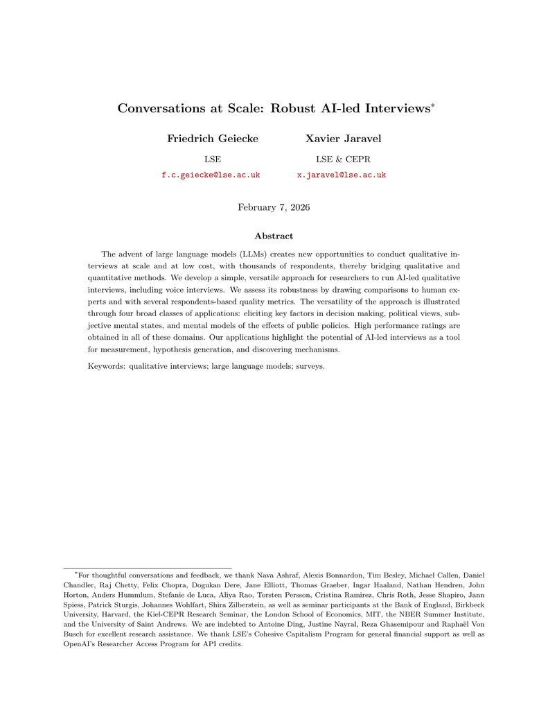

They build an AI-led interview platform and use it in several substantive applications. Their evaluation compares human and AI interviewers, text and voice input, prompts and models.

The paper therefore speaks to several design choices separately rather than treating “AI interviewing” as one condition.

## Their text interface sends the conversation back to the model after each answer

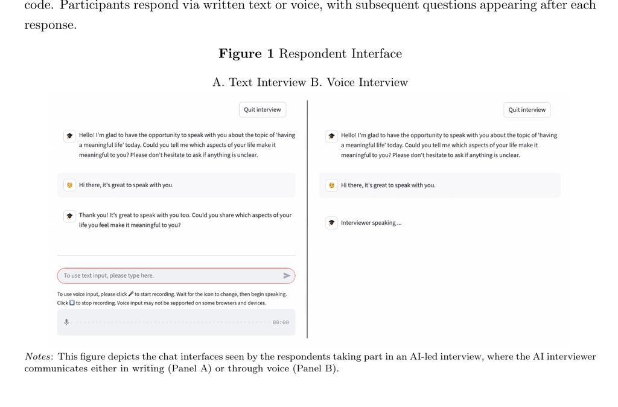

1. Streamlit displays the chat.
2. The platform keeps the system prompt and chat history.
3. The participant’s new answer is added.
4. The LLM generates the next question.
5. The new turn is displayed and logged.

**Input to the model:** instructions plus conversation so far. **Output:** the next interviewer question as text.

## Voice can mean two different technical arrangements

### A modular pipeline

Speech-to-text transcribes the answer; a text model writes a question; text-to-speech reads it aloud.

Each component can have a different provider, model and retention policy.

### A native audio model

Audio enters and audio leaves one model, although a transcript may still be produced for display or analysis.

Voice, latency and prosody become part of the interviewer.

Geiecke & Jaravel (2026), section 3.4.2 and note 43. Their 2025 inflation study used Whisper for transcription and `gpt-4o-audio-preview-2024-12-17` with the “coral” voice for audio output.

## Geiecke and Jaravel report higher grades when participants speak

Eight sociology PhD students graded transcripts against what a human expert might achieve.

With the same baseline prompt and GPT-4o, the mean grade was:

2.82 with typed answers  
3.63 with spoken answers

The authors argue that speaking produced more information, which allowed more precise follow-up.

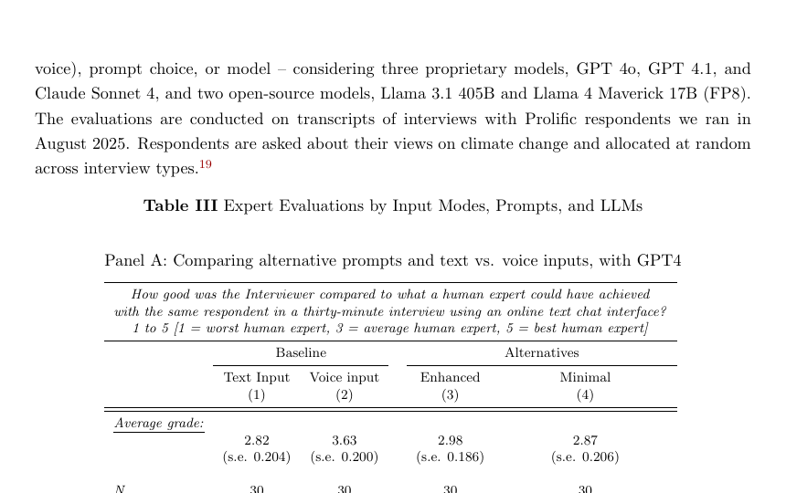

Geiecke & Jaravel (2026), Table III, Panel A. Thirty transcripts per condition; these are expert ratings, not a direct measure of truth or rapport.

## The stronger voice result is informative, but it does not settle the method

### What it shows

Mode changed the information participants supplied and the transcripts sociologists evaluated.

### What it cannot show alone

Whether accounts were more accurate, whether all topics benefit, or how voice changes disclosure.

### What to record

Input and output mode, transcription model, voice model, voice setting, latency and participant edits.

Voice is not merely a more convenient interface. It changes the interaction and possibly the evidence.

## Wuttke and colleagues compare where AI and student interviewers go wrong

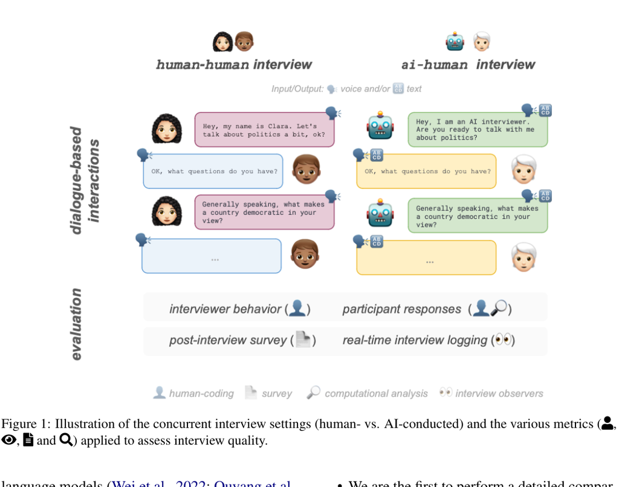

Participants discussed politics and democracy with either an AI or a human student interviewer.

The AI used GPT-4 Turbo in a Chainlit interface. Participants could choose text or voice for both input and output; speech recognition used Whisper.

The study included five AI-led and six human-led interviews, so the detailed error comparison is exploratory.

Alexander Wuttke et al. (2025), “AI Conversational Interviewing,” *LaTeCH-CLfL 2025*: 132–144.

## Human and AI interviewers missed different things

### AI interviewer

- often failed to pursue surprising or unclear answers;
- sometimes evaluated or praised responses;
- produced longer turns and suffered latency/transcription problems.

### Student interviewers

- more often failed to show active listening;
- sometimes guided the participant’s answer;
- were not an expert-interviewer benchmark.

The paper does not establish that one interviewer type is simply better. It identifies different failure patterns that training and system design would need to address.

Wuttke et al. (2025), pp. 137–140 and Table 1. Human coders judged response quality broadly similar in this small sample.

## Jack, Cooper and Flower provide a larger sociological field example

### Who?

74 social scientists at a Swedish university.

### What?

A chatbot interviewed them about their own use of generative AI.

### Follow-up?

23 participants later described the experience by email.

This is an actual AI-mediated qualitative study, not only a benchmark or hypothetical system.

Tullia Jack, Alex Cooper & Lisa Flower (2026), “Automating the Qualitative Interview? Using Gen AI Chatbots in Social Science Research,” *Methodological Innovations*, advance online publication. https://doi.org/10.1177/20597991261448157

## Finishing an interview is not the same as producing a good one

Jack and colleagues show that simultaneous adaptive interviews can elicit substantial text at scale. Participants’ follow-up accounts also raised repetition, limited nuance and a weaker sense of interaction.

### Operational evidence

Completion, length, duration and system logs show whether the interview ran.

### Methodological evidence

Transcript review and participant follow-up show whether the exchange produced specificity, depth and a credible relationship.

## Cuevas et al. randomly assigned 399 participants to three chatbot designs

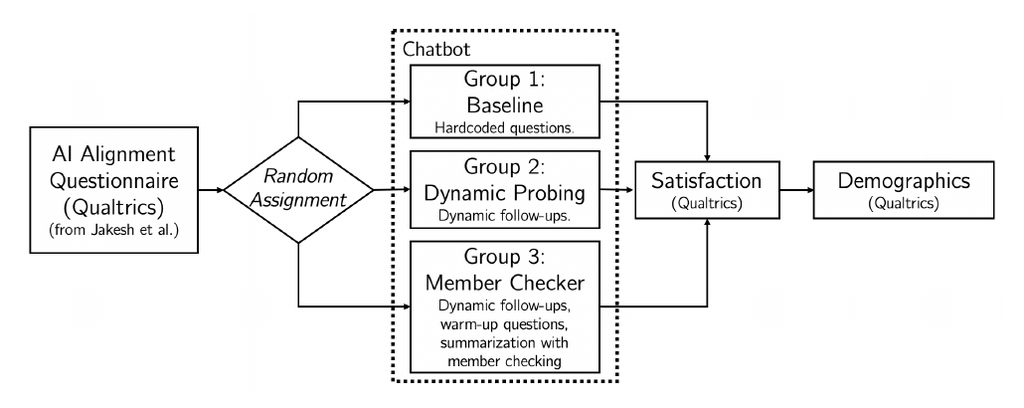

Cuevas et al. (2025), Figure 2, “Collecting Social Data with Large Language Models,” *PACM HCI*. https://doi.org/10.1145/3710947

## Here is what the three conditions actually did

| Condition | After each main answer | At the end |
| --- | --- | --- |
| **Fixed baseline** | Asked the same two probes: “Can you elaborate?” and “Can you provide an example?” | Ended the conversation. |
| **Dynamic Prober** | GPT-3.5 Turbo read the participant’s answer and wrote two follow-up questions for that answer. | Ended the conversation. |
| **Dynamic Prober + Member Checker** | Used the same generated follow-ups, with an additional warm-up question. | Generated a summary that the participant could confirm or contest. |

**What was compared:** engagement, participant experience, conversational quality and qualitative richness. Both adaptive conditions used GPT-3.5 Turbo through Azure OpenAI; the 399 participants provided 4,308 open-ended responses.

Cuevas et al. (2025), Sections 3.3, 4.2, 5 and Appendix D.

## The adaptive chatbot improved follow-up without reliably producing depth

The Dynamic Prober improved the study’s follow-up score. Across most other quality measures, the LLM conditions looked similar to the fixed baseline.

Responses were usually clear and relevant, yet often lacked:

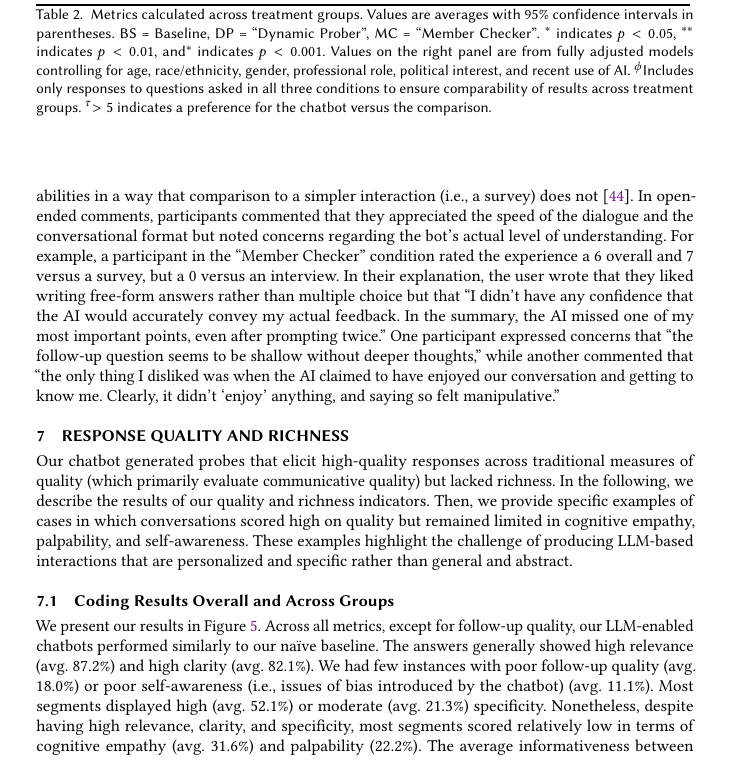

Cuevas et al. (2025), sections 6–8. The authors call these systems “adaptive surveyors, not automated interviewers.”

## A participant objected when the bot claimed to enjoy the conversation

The Member Checker used friendly conversational language after the interview. One participant thought that wording attributed an emotional capacity to the system that it did not have.

“Clearly, it didn’t ‘enjoy’ anything, and saying so felt manipulative.”

This tells us how one participant interpreted the relationship the chatbot was performing. It does not tell us that every participant reacted in the same way.

Cuevas et al. (2025), p. 14.

## Panfilova and colleagues hold the interview design fixed and change the model

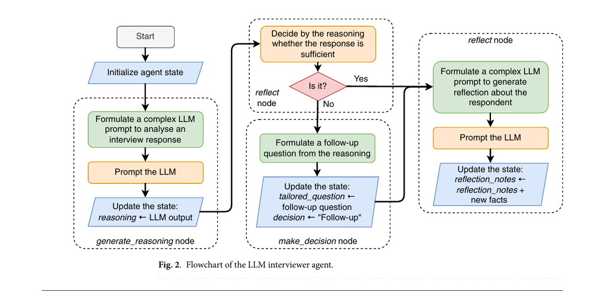

Six models received the same prompts, guardrails and interview workflow. Each processed the same baseline interview material, making model choice the main difference between conditions.

The follow-up answers came from a fixed simulated interviewee. This is a controlled benchmark, not evidence from interviews with people.

Panfilova et al. (2026), *Scientific Reports*. DOI: 10.1038/s41598-026-46517-7.

## Model choice changed speed, follow-up rate and interviewer style

Across ten standardized interviews, models differed substantially in time and number of follow-ups.

For example, the reported average interview time ranged from about nine minutes for GPT-5 Chat to more than two hours for Qwen3-235B A22B.

Gemini 2.5 Pro more often used emphatic, appreciative phrasing. The paper treats this as a model-specific style—not proof that participants experienced greater empathy.

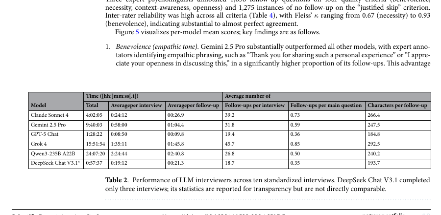

Panfilova et al. (2026), Table 2 and Results. DeepSeek completed only three interviews and is not directly comparable.

## The studies use different evidence to answer different questions

| Evidence and source | What it helps us assess | What it cannot settle alone |
| --- | --- | --- |
| Protocol/error coding — Wuttke et al. | Missed probes, leading questions, active listening | Performance by expert interviewers |
| Sociologist transcript ratings — Geiecke & Jaravel | How evaluators judged resulting transcripts | Truth, rapport or behavioral validity |
| Participant experience — Jack et al.; Cuevas et al. | How the exchange felt and where it frustrated | Accuracy of the account |
| Richness coding — Cuevas et al. | Specificity, palpable examples, perspective | Whether these exhaust qualitative quality |
| Controlled model comparison — Panfilova et al. | Model-specific style, speed and follow-up behavior | Field interaction with human participants |

## Remember the two interviews from the opening

Interview A

**Evaluator:** The conversation flowed. We had a surprising amount in common.

**Interviewer:** What did you find you had in common?

Interview B

**Evaluator:** The conversation flowed. We had a surprising amount in common.

**Interviewer:** So their background matched the firm’s culture?

Interview A asks the evaluator to specify the comparison. Interview B introduces the researcher’s preferred explanation. Which is preferable still depends on the research aim and the claim we later make.

## The worked example has one research aim and one probing rule

Research aim

How do evaluators decide that a candidate is a good cultural fit?

Fixed opening question

Tell me about a recent candidate who seemed like a good fit for the firm.

Rule for the next probe

Ask for a concrete judgment, episode or comparison. Do not name class background, similarity or another cause unless the evaluator has already done so.

The interview can help us understand how evaluators explain their judgments. It cannot by itself show how often cultural similarity changes an actual hiring decision.

## One path identifies a shared activity

Evaluator: The conversation flowed. We had a surprising amount in common.

Adaptive probe: What did you find you had in common?

Evaluator: We had both rowed in college and talked about long training days.

The probe asks the evaluator to specify the comparison. It does not name similarity as the cause of the hiring judgment.

## Another path identifies an image of the firm

Evaluator: She understood how we work with clients. I could picture her here.

Adaptive probe: What did she say or do that made you picture her working here?

Evaluator: She challenged the case assumption without becoming combative.

## The same system produced different interview paths

|  | A | B |
| --- | --- | --- |
| Fixed questions | 1 | 1 |
| Adaptive probes | 1 | 1 |
| Evidence elicited | Shared rowing experience | How the candidate handled disagreement |
| Inspect | Exact wording, link to prior response, direction, relevance and stopping decision |  |

## The Python task generates one probe and records where it came from

1**Input**

Interview brief and ordered conversation turns

2**Model call**

Ask for one follow-up that follows the probing rule

3**Output**

The exact proposed question

4**Record**

Append the question and link it to the answer it follows

The model proposes the next question. We still inspect whether it follows the participant’s words, avoids introducing a cause, and serves the research aim.

## First, turn the interview brief and conversation into model messages

```python
import json

INTERVIEW_PROTOCOL = """
Research aim: understand how evaluators decide that a candidate
is a good cultural fit.
Ask one follow-up question. Request a concrete episode,
clarification, or consequence. Do not introduce a cause.
Return only the question.
"""

opening_question = (
    "Tell me about a recent candidate who seemed like a good fit."
)
first_answer = (
    "The conversation flowed. We had a surprising amount in common."
)
turns = [
    {"role": "interviewer", "text": opening_question},
    {"role": "participant", "text": first_answer},
]

messages = [
    {"role": "system", "content": INTERVIEW_PROTOCOL},
    {"role": "user", "content": json.dumps(turns, indent=2)},
]
```

**Input**  
Two strings become two turn dictionaries inside the ordered `turns` list.

**Output**  
`json.dumps(…)` converts that list into readable text inside `messages`.

## Then ask the model for one adaptive probe

```python
reply = client.chat.send(
    model=INTERVIEW_MODEL,
    messages=messages,
    temperature=0,
    stream=False,
)

next_probe = reply.choices[0].message.content.strip()
```

Model output

What did you find you had in common?

`next_probe` is a string. Before using it, the interviewer or software should check it against the probing rule.

## Store the generated question as the next turn

```python
probe_turn = {
    "role": "interviewer",
    "text": next_probe,
    "topic": None,
    "source": "adaptive_probe",
    "responds_to": len(turns),
}

turns.append(probe_turn)
```

**Before**  
`turns` ends with the participant’s answer.

**After**  
`turns` also contains the generated probe and its link to that answer.

## Each turn is one dictionary inside a list

```python
turns = [{
    "role": "interviewer",
    "text": next_probe,
    "topic": None,
    "source": "adaptive_probe",
    "responds_to": 2,
}]
```

**List:** preserves order. **Dictionary:** stores named fields for one turn. `topic` is still `None` because the researcher has not yet added an analytic label.

## Read one record from left to right

`role`  
transcript log  
who spoke

`text`  
transcript log  
exact words

`source`  
decision log  
protocol or probe

`responds_to`  
decision log  
prior turn link

`topic`  
researcher annotation  
analytic label

## Speech-to-text turns the recording into text the interviewer model can read

```python
with open("answer.wav", "rb") as audio_file:
    stt_result = speech_client.audio.transcriptions.create(
        model=STT_MODEL,
        file=audio_file,
    )

answer_text = stt_result.text
```

### Input

`answer.wav`: recorded participant audio.

### Output

`answer_text`: a string added to the conversation.

Listen for errors in names, accents, code-switching, overlap and emotional speech. Allowing transcript correction may improve accuracy but changes the interview flow.

## OpenRouter handles the text interviewer in our class setup

```python
messages.append({"role": "user", "content": answer_text})

reply = client.chat.send(
    model=INTERVIEW_MODEL,
    messages=messages,
    temperature=0,
    stream=False,
)

next_probe = reply.choices[0].message.content.strip()
```

**Input:** instructions and conversation including the new transcript. **Output:** one proposed interviewer turn. Store the selected provider, model identifier and exact output.

## Text-to-speech makes that question audible

```python
from pathlib import Path

with speech_client.audio.speech.with_streaming_response.create(
    model="gpt-4o-mini-tts",
    voice="coral",
    input=next_probe,
    instructions="Speak at a measured pace."
) as response:
    response.stream_to_file(Path("probe_coral.mp3"))
```

**Input:** `next_probe`, a voice name and delivery instructions. **Output:** `probe_coral.mp3`, an audio file that can be played to the participant.

Voice and instructions are part of the interview stimulus. A warmer, faster or more authoritative delivery may change disclosure and perceived attention.

## Test several voices while keeping the question fixed

```python
voices = ["coral", "marin", "cedar"]

for voice in voices:
    output_file = Path(f"probe_{voice}.mp3")
    with speech_client.audio.speech.with_streaming_response.create(
        model="gpt-4o-mini-tts",
        voice=voice,
        input=next_probe,
        instructions="Speak at a measured pace.",
    ) as response:
        response.stream_to_file(output_file)
```

**probe_coral.mp3**

**probe_marin.mp3**

**probe_cedar.mp3**

Because the wording and instruction stay fixed, the comparison isolates the selected voice. Ask what changes in perceived authority, warmth, patience or pressure.

OpenAI Audio API, “Create speech,” accessed 27 August 2026. The demonstration uses no research data.

## Save the generated probe with the answer that prompted it

```python
probe_record = {
    "participant_answer": first_answer,
    "generated_probe": next_probe,
    "source": "adaptive_probe",
    "model": INTERVIEW_MODEL,
}

print(probe_record)
```

**Input:** the participant’s answer, the generated question and the model name. **Output:** one dictionary preserving the connection between them.

## A list can preserve each interview turn in order

```python
conversation = [
    {"role": "interviewer", "text": opening_question},
    {"role": "participant", "text": first_answer},
    {"role": "interviewer", "text": next_probe},
]

print(conversation[2]["text"])
```

**`conversation`**  
A list. Its order records what happened first, second and third.

**`conversation[2]`**  
The third dictionary. Python starts counting at zero.

## Now add the participant’s next answer

```python
second_answer = (
    "We had both worked on the college newspaper, "
    "so the conversation became much more informal."
)

conversation.append({
    "role": "participant",
    "text": second_answer,
})

print(conversation)
```

`.append(…)` changes the list by adding one new item at the end. That expanded conversation becomes the input to the next model call.

## The record lets us inspect the generated question directly

| Check | What to inspect | Why it matters |
| --- | --- | --- |
| Responsive? | Does the probe refer to something in the participant’s answer? | A generic question does not make use of adaptation. |
| Leading? | Does it introduce “cultural fit” or another cause the participant did not name? | The interviewer may manufacture the explanation. |
| Specific? | Does it ask for a decision, episode or comparison? | Concrete evidence is easier to assess than a general opinion. |

## The completion task is deliberately small

Generate one adaptive probe, add one participant answer, and explain orally:

1. what each string stores;
2. what the model received;
3. what the returned string contains;
4. how `.append()` changes the conversation list;
5. why a responsive question can still be leading or methodologically weak.

## Build the source record while the interview runs

### Before

Research question, protocol, consent, system instructions, models, route, speech settings and escalation rules.

### During

Ordered turns, exact prompts and outputs, probe links, human approvals/edits, latency and errors.

### After

Validation evidence, transcript corrections, analysis decisions, retention, deletion and access.

A transcript is one part of this record. It does not show how the system decided what to ask next.

## What would you need to know before treating this transcript as sociological evidence?

1. What is the interview meant to establish?
2. Which decisions were fixed, selected, generated or human-approved?
3. What did this participant actually experience?
4. What evidence validates the interview for that research purpose?

Next week: whether models can stand in for people or populations.